# Status loss and participation

## Status loss, continued participation

Stack Overflow · Main findings

Research discussion · November 2026

## Agenda

1. Activity over **26 weeks before and 26 after**
2. PSM and CEM: prior covariates, group means and outcome estimates
3. Calipers 0.20, 0.25 and 0.30: estimated outcome sensitivities
4. Continuous loss: supported shifts and the preprint’s DiD
5. Text coverage and the remaining data requirement

## Reputation loss: activity, expression and context

### Contribution

Do users contribute more or less?

### Expression

Do tone and emotions change?

### Context

Where do users express thanks?

The 2010 policy change reduced question-upvote rewards from **+10 to +5** and applied retroactively. The analysis reconstructs each user’s reputation loss from their question-vote history before implementation.

**Treated:** users with the measured reputation loss. **Comparison:** users without that loss; they may still ask questions. The comparison is not exposure versus no exposure to every part of the policy change. [Rule change, March 19, 2010](https://stackoverflow.blog/2010/03/19/important-reputation-rule-changes/) · [Recalculation, March 21](https://stackoverflow.blog/2010/03/21/the-great-reputation-recalc-begins/).

## 1 · Activity analysis

Activity descriptives and DiD: no control, weekly volume, or days with other activities.

## Activity before and after the reform

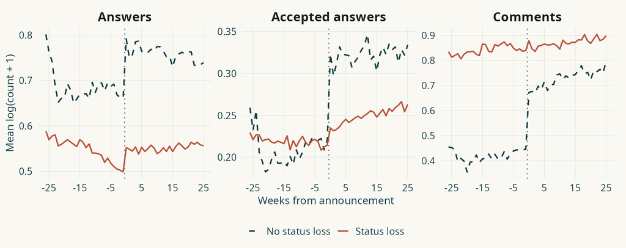

Weekly mean of log(count + 1) by group, ±26 weeks, as in code/analysis/02_descriptive.R. Only active user-weeks (any question, answer or comment); 85,605 users. Dashed petrol: no status loss; solid terracotta: status loss. Week 0 is the first seven days after announcement.

Weekly mean of log(count + 1) by group, ±26 weeks, as in code/analysis/02_descriptive.R. Only active user-weeks (any question, answer or comment); 85,605 users. Dashed petrol: no status loss; solid terracotta: status loss. Week 0 is the first seven days after announcement.

**Descriptive levels, not effects.** Groups differ before the reform and both shift at the announcement; the models compare these changes.

## Three specifications of weekly activity

```r
# CONTROL 1: number of contributions per user-week (accepted answers are in a).
d[, weekly_activity_volume := q + a + c]

# CONTROL 2: distinct active days with OTHER contribution types (0..7).
# x contains contribution timestamps aligned to the original t_week/activity_day.
days = x[, .(
  days_questions_answers = uniqueN(activity_day[post_type %in% c("question", "answer")]),
  days_questions_comments = uniqueN(activity_day[post_type %in% c("question", "comment")])
), by = .(user_id, t_week)]
d = merge(d, days, by = c("user_id", "t_week"), all.x = TRUE)
d[is.na(days_questions_answers), days_questions_answers := 0L]
d[is.na(days_questions_comments), days_questions_comments := 0L]
# Comments use Q/A days; answers and accepted answers use Q/comment days.
control_for = c(c_log = "days_questions_answers", a_log = "days_questions_comments",
               aa_log = "days_questions_comments")

# THREE SEPARATE MODELS: each adjusted model uses ONE of the two controls.
xformulas = list(no_control = ~1,
                 volume = ~weekly_activity_volume,
                 active_days = reformulate(control_for[[outcome]]))
# att_gt(..., xformla = xformulas[[specification]])
```

**Input.** `d`: observed user-weeks; `x`: dated questions, answers and comments.

**Objects.** `days`: distinct days by user-week. Merge into `d`; `control_for` selects the other-activity measure for each outcome.

**Result.** `xformulas`: three alternative formulas. The two controls never enter together; `37` fits the comparison matrix.

Code excerpt: `36_weekly_active_days_models.R → 37_psm_activity_reestimate.R`. Objects are prepared by the full script.

**Three separate models:** no control, weekly volume, or days with other activities. Both controls refer to the outcome week; they never enter together. Adjusted results are conditional comparisons.

## Unmatched DiD: comparison and uncertainty

```r
# Same call as the current PSM comparison; no-matching weights start at one.
z[, `:=`(observation_id = .I, user_cluster = user_id,
         time = t_week, g = treated, case_weight = 1)]
X = switch(specification,
  "No activity control" = ~1, "Weekly total contributions" = ~weekly_activity_volume,
  "Days with other contributions" = reformulate(control_for[[outcome]]))
fit = att_gt(yname = outcome, tname = "time", idname = "observation_id",
  gname = "g", data = z, panel = FALSE, clustervars = "user_cluster",
  weightsname = "case_weight", xformla = X,
  est_method = "reg", control_group = "nevertreated", anticipation = 0,
  base_period = "varying", bstrap = TRUE, biters = 1000, cband = TRUE)
```

**Input.** `z`: original observed user-weeks; weights equal one in the unmatched weekly model.

**Objects.** `observation_id` identifies a row; `user_cluster` identifies the person; `X` selects one outcome formula.

**Result.** `fit`: group-time estimates. `aggte` extracts average and weekly effects for the result tables and plots.

Code excerpt: `37_psm_activity_reestimate.R`. Objects are prepared by the full script.

85,605 users; 452,116 observed active user-weeks. No direct history covariates in the unmatched main model. No added inactive weeks; uncertainty grouped by user.

## Unmatched DiD: negative relative change in comments

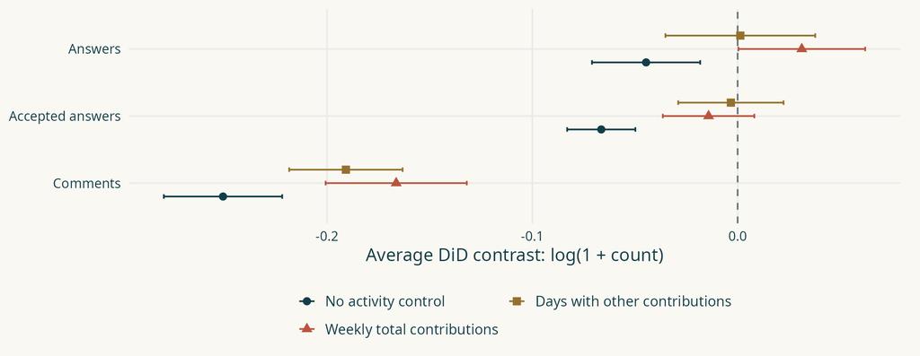

Unmatched DiD; identical sample and outcome-regression estimator. Point estimates and 95% intervals on log(1 + count).

Unmatched DiD; identical sample and outcome-regression estimator. Point estimates and 95% intervals on log(1 + count).

**Main model, last pre week:** treated +0.032; comparison +0.283; DiD **−0.251** in log(1 + comments). Both increase; comparison users increase more. Weekly-activity adjustments are separate conditional checks.

## Weekly DiD: answers

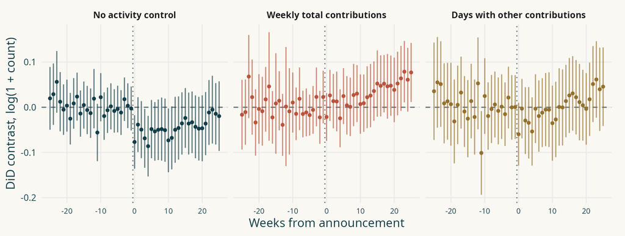

Same vertical scale across specifications. Simultaneous 95% bands within each fitted event study; no joint correction across specifications.

Same vertical scale across specifications. Simultaneous 95% bands within each fitted event study; no joint correction across specifications.

Read pre-period contrasts and post-period persistence separately; average effects need not describe every week.

## Weekly DiD: accepted answers

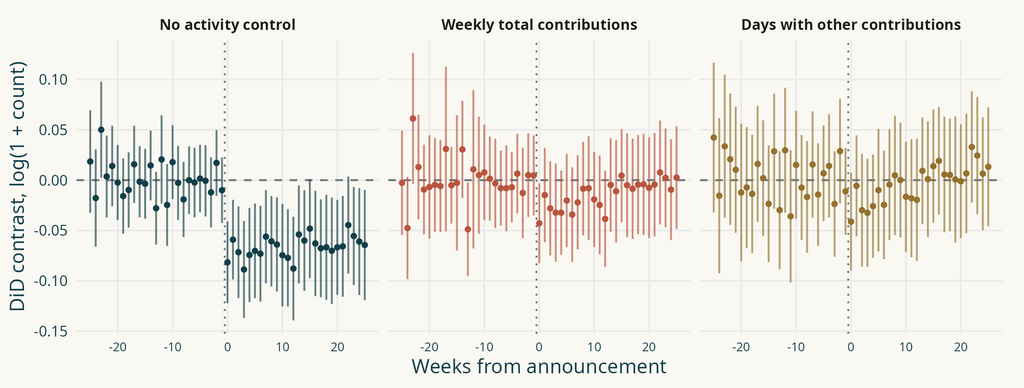

Same vertical scale across specifications. Simultaneous 95% bands within each fitted event study; no joint correction across specifications.

Same vertical scale across specifications. Simultaneous 95% bands within each fitted event study; no joint correction across specifications.

Read pre-period contrasts and post-period persistence separately; average effects need not describe every week.

## Weekly DiD: comments

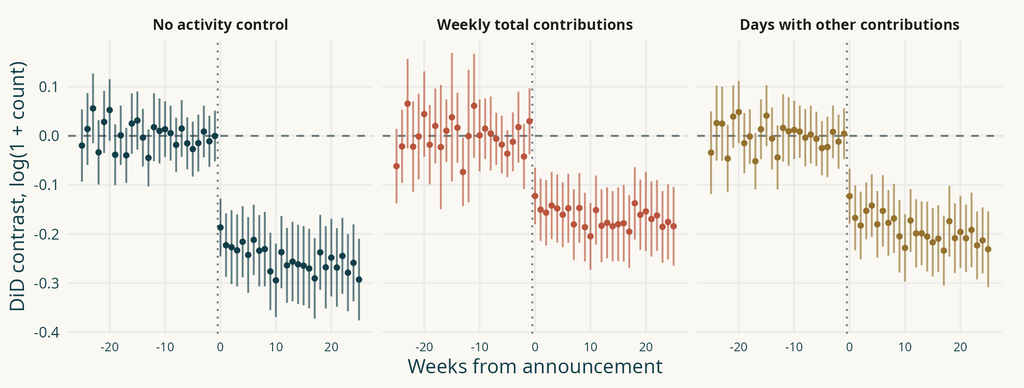

Same vertical scale across specifications. Simultaneous 95% bands within each fitted event study; no joint correction across specifications.

Same vertical scale across specifications. Simultaneous 95% bands within each fitted event study; no joint correction across specifications.

Read pre-period contrasts and post-period persistence separately; average effects need not describe every week.

## 2 · Matching

Balance pre-policy characteristics through selection and weights, then compare outcome changes. Both replacement designs remain in the main analysis.

## Before the results: what PSM and CEM do

| Step | PSM: propensity score matching | CEM: coarsened exact matching |
| --- | --- | --- |
| Same inputs | Prior comments, answers, reputation and tenure | The same four pre-policy characteristics |
| Build the comparison | Estimate the probability of belonging to the treated group from prior history | Divide each characteristic into bands and cross the four band labels |
| Retain users | Choose nearby controls by Mahalanobis distance, subject to propensity-logit and covariate calipers | Keep strata with both treated and control users, subject to our 10:1 cap |
| Construct weights | 1:1 matching; control reuse is a separate fitted design | Weight controls to reproduce the treated distribution across retained strata |

Both methods select a comparison population using pre-policy history. We then estimate DiD on the retained users and their weights.

The propensity score predicts treatment-group membership, not an outcome. Matching alone does not establish parallel trends or balance unobserved characteristics.

## CEM: exact matches on bands of prior history

| Prior characteristic | Example band | Two users in this band may differ |
| --- | --- | --- |
| Comments in the 26 pre weeks | 3–5 comments | 3 versus 5 comments |
| Prior answers | 6–10 answers | 6 versus 10 answers |
| Prior reputation | 100 to less than 200 points | 120 versus 180 points |
| Tenure | 26 to less than 52 weeks | 30 versus 45 weeks |

A CEM stratum is the combination of **all four bands**. “Exact” refers to the band labels; the original values can differ within a band.

Illustrative values using the fixed-band design’s actual boundaries. Keep a stratum only if it has both groups and at most 10 treated users per control; other strata are excluded.

## CEM weights: make the strata comparable

| Illustrative retained stratum | Treated users | Control users | Weight per treated user | Weight per control user |
| --- | --- | --- | --- | --- |
| A: one combination of four bands | 2 | 4 | 1 | 0.5 |
| B: another combination of four bands | 4 | 2 | 1 | 2 |

In A, four controls carry total weight 2; in B, two controls carry total weight 4. The weighted control distribution matches the treated distribution across strata.

Illustration, not estimated sample counts. In the fitted data: treated weight = 1; control weight = (all retained controls / all retained treated) × (treated / controls in that stratum). The common normalization leaves weighted means unchanged.

## PSM 1:1 uses original prior-history variables

```r
covs = c("pre_comments", "tenure", "reputation_pre", "n_answers_pre")
base_args = list(formula = reformulate(covs, response = "treated"),
  data = frame, method = "nearest", distance = "glm", link = "linear.logit",
  estimand = "ATT", ratio = 1,
  caliper = c(0.2, reputation_pre = 0.2, n_answers_pre = 0.2),
  std.caliper = TRUE, mahvars = reformulate(covs))
m1 = do.call(matchit, c(base_args, list(replace = FALSE, m.order = "closest")))
# match.data(m1) supplies retained IDs and matching weights.
```

**Input.** `frame`: one row per eligible user; `covs`: four prior-history variables in original units.

**Objects.** `base_args`: propensity model, Mahalanobis inputs and calipers. `m1`: fitted 1:1 match without replacement.

**Result.** `match.data(m1)`: retained users and weights. These are joined to observed outcomes before fitting DiD.

Code excerpt: `37_psm_activity_reestimate.R`. Objects are prepared by the full script.

33,893 matched pairs; **68.3% of eligible treated users retained**. No log/asinh predictors and no prior-question eligibility or matching variable. Standardized calipers are distance limits, not transformed inputs.

## PSM with replacement reuses eligible controls

```r
# Same four variables, propensity model, Mahalanobis inputs and calipers.
m2 = do.call(matchit, c(base_args, list(replace = TRUE)))
users = as.data.table(match.data(m2))[, .(user_id, treated, weight = weights)]
# Reused controls are represented once with their matching weight.
ess = users[, .(users = .N,
                effective_n = sum(weight)^2 / sum(weight^2)), by = treated]
```

**Input.** The same `frame` and `base_args`; replacement is now allowed.

**Objects.** `m2`: fitted replacement match. `users`: one row per retained person, with their matching weight.

**Result.** `ess`: effective sample size by treatment group. Coverage and weight concentration are diagnostics, not DiD effects.

Code excerpt: `37_psm_activity_reestimate.R`. Objects are prepared by the full script.

47,603 treated users retained (**96.0%**), with 10,343 distinct eligible controls. Control effective N: **1,654**. Reuse increases coverage while concentrating weights.

## CEM uses the same four prior-history covariates

| Prior covariate | Fixed-band CEM | Empirical CEM |
| --- | --- | --- |
| Prior comments | Prespecified count bands | Same bands |
| Tenure | Prespecified week bands | Same bands |
| Prior reputation | Prespecified point bands | Same bands |
| Prior answers | 0; 1–2; 3–5; 6–10; 11–20; 21–50; 51+ | Pooled answer-count decile boundaries; duplicate cuts removed |

Keep strata containing both groups; controls are weighted to the treated stratum distribution. The outcome DiD is then estimated using those weights.

Prior comments use all 26 pre weeks. Maximum 10 treated users per control within retained strata. No question-history eligibility filter. CEM and PSM enter every activity outcome specification.

## PSM and CEM use the same 26-week windows

| Comparison family | How prior histories are compared | Outcome window |
| --- | --- | --- |
| No matching | All eligible observed users | 26 pre / 26 post weeks |
| PSM: no control reuse | Calipers 0.20 / 0.25 / 0.30 | Same 52 weeks |
| PSM: control reuse allowed | The same three calipers; control weights | Same 52 weeks |
| CEM: fixed bands | Four prior covariates crossed into strata | Same 52 weeks |
| CEM: answer deciles | Same strata except prior-answer cuts | Same 52 weeks |

**Nine fitted designs.** Each has two time references and three activity specifications: 162 average comparisons, plus their weekly estimates.

Time references: last pre week, or all 26 pre weeks with equal group-week weighting. Main DiD has no contemporary activity control; volume and other-activity days are additional fitted specifications.

## Time baselines: how the comparisons are built

```r
z = merge(d, matched_ids[, .(user_id, match_weight = weight)], by = "user_id")
z[, `:=`(observation_id = .I, user_cluster = user_id)]
# Weekly model: last pre week is the comparison base.
z[, `:=`(time = t_week, g = treated, case_weight = match_weight)]
# Broad-pre model: formal two-period DiD, equal weight per observed group-week.
z[, `:=`(time = ifelse(t_week < 0, 1L, 2L), g = 2L * treated)]
z[, case_weight := match_weight / sum(match_weight), by = .(treated, t_week)]
z[, case_weight := case_weight / uniqueN(t_week), by = .(treated, time)]
```

**Input.** `d`: weekly outcomes; `matched_ids`: retained users and weights for one design.

**Objects.** `z`: their joined records. The weekly and broad-pre blocks are alternative preparations, not consecutive models.

**Result.** `time`, `g`, `case_weight`: the time coding, treatment timing and observation weights passed to `att_gt`.

Code excerpt: `37_psm_activity_reestimate.R`. Objects are prepared by the full script.

The broad-pre model keeps original weekly observations and covariates. It gives each week equal weight within each group-period; it does not first collapse data to user-period means.

## DiD estimation: weights, covariates and outputs

```r
fit = att_gt(yname = outcome, tname = "time", idname = "observation_id",
  gname = "g", data = z, panel = FALSE, clustervars = "user_cluster",
  weightsname = "case_weight", xformla = ~1,
  est_method = "reg", control_group = "nevertreated", anticipation = 0,
  base_period = "varying", bstrap = TRUE, biters = 1000, cband = TRUE)
average = aggte(fit, type = "simple")
# Weekly-reference models also use aggte(fit, type = "dynamic").
```

**Input.** Prepared `z`; matching enters through `case_weight`. `xformla = ~1`: no contemporary activity covariate.

**Objects.** `fit`: group-time effects; `average`: aggregated effect. A separate dynamic aggregation supplies weekly estimates.

**Result.** 54 no-activity-control average comparisons → `activity_average_estimates.csv`; weekly-reference estimates → `activity_weekly_estimates.csv`.

Code excerpt: `37_psm_activity_reestimate.R`. Objects are prepared by the full script.

Repeated-cross-section estimation with original-user clustering. Average intervals: ±1.96 × SE. Weekly plots use each event study’s simultaneous critical value. Matching is held fixed in inference.

## Each adjustment has a separate role

| Analysis | Prior-history adjustment | Outcome-stage adjustment |
| --- | --- | --- |
| Binary activity DiD | PSM or CEM weights; nine designs | None in main; weekly-volume and other-day sensitivities |
| Supported continuous shifts | Six raw prior variables + prior outcome mean | Linear interactions and additive GAM |
| Preprint continuous DiD | Official CCK implementation; no covariates | Dose versus zero loss; different estimand |
| Text and context | Same 26-week contract for future PSM/CEM fits | Awaiting missing post-policy comment data |

Matching variables precede the policy. Weekly activity controls can respond to it, so those specifications describe conditional comparisons.

## What bootstrap replications mean

| Analysis | Replications | What is repeated |
| --- | --- | --- |
| PSM / CEM DiD | 1,000 multiplier bootstrap replications | Random user-level multipliers perturb estimated contributions; matching and its weights stay fixed |
| Supported GAM / linear shifts | 200 bootstrap resamples of users | Sample users with replacement and refit; support, spline basis and smoothing penalties stay fixed |
| Preprint continuous DiD | 999 Gaussian multiplier bootstrap replications | Gaussian random weights perturb the estimated curve to construct uncertainty bands |

A replication (sometimes called a “draw”) is one random bootstrap iteration used to quantify uncertainty. It is not an additional observed user.

Pointwise intervals cover one estimate at a time. Uniform bands cover the displayed curve jointly within one fitted outcome; they do not cover every model in the presentation jointly.

## Matching eligibility and observed activity are distinct

| Design | Eligible treated | Eligible controls | Treated observed in activity | Controls observed in activity |
| --- | --- | --- | --- | --- |
| No matching | 49,588 | 47,071 | 43,906 | 41,699 |
| PSM 0.20: no reuse | 33,893 | 33,893 | 29,974 | 28,549 |
| PSM 0.20: reuse | 47,603 | 10,343 | 41,928 | 8,148 |
| CEM: fixed bands | 20,048 | 46,045 | 17,614 | 40,796 |
| CEM: answer deciles | 19,951 | 45,838 | 17,513 | 40,588 |

Covariate means describe retained matching users. Outcome models use the retained users who have observed activity in the required window.

No added inactive weeks. Effective control counts in the matching diagnostics describe the matching weights; they are not a count of weekly observations.

## How to read the covariate mean tables

| Column | Meaning |
| --- | --- |
| Before: treated / controls | Mean in each group of the full eligible matching frame |
| After: treated / controls | Mean among retained users, using the design weights |
| Mean gap after matching | Treated mean minus control mean, in the original units |
| Standardized gap: before → after | The mean gap divided by the same pre-match pooled standard deviation |

Means explain the size of the difference. Standardized gaps allow comparisons across covariates measured in different units.

Four matching inputs only: prior comments, prior answers, prior reputation and tenure. A small standardized gap does not prove parallel trends.

## What the four matching covariates measure

| Covariate | Units and construction |
| --- | --- |
| Prior comments | Count in the complete 26-week pre-policy window, reconstructed from the raw JSONs |
| Prior answers | All recorded answers before the announcement, as in the original design |
| Prior reputation | Accumulated recorded reputation changes before the announcement |
| Tenure | Weeks from the recorded user start to the announcement |

All histories are measured before the policy. Recent commenting and cumulative histories are different variables; the outcome window is always 26 pre / 26 post weeks.

## Covariate means: PSM 0.20: no reuse

| Covariate | Before: treated | Before: controls | After: treated | After: controls | Mean gap after matching | Standardized gap: before → after |
| --- | --- | --- | --- | --- | --- | --- |
| Prior comments | 9.59 | 1.78 | 2.45 | 1.69 | +0.75 | +0.241 → +0.023 |
| Prior answers | 10.85 | 3.88 | 3.59 | 3.64 | -0.05 | +0.170 → -0.001 |
| Prior reputation | 306.15 | 73.58 | 89.11 | 71.54 | +17.57 | +0.218 → +0.016 |
| Tenure (weeks) | 26.93 | 19.08 | 21.82 | 21.82 | +0.00 | +0.470 → +0.000 |

After matching: **33,893 treated / 33,893 distinct controls**. Effective controls: 33,893.

Original units; weighted means after matching. Before matching: 49,588 treated and 47,071 controls. Column definitions.

## Covariate means: PSM 0.20: reuse

| Covariate | Before: treated | Before: controls | After: treated | After: controls | Mean gap after matching | Standardized gap: before → after |
| --- | --- | --- | --- | --- | --- | --- |
| Prior comments | 9.59 | 1.78 | 5.04 | 4.73 | +0.31 | +0.241 → +0.010 |
| Prior answers | 10.85 | 3.88 | 5.47 | 5.49 | -0.02 | +0.170 → -0.000 |
| Prior reputation | 306.15 | 73.58 | 156.97 | 152.09 | +4.88 | +0.218 → +0.005 |
| Tenure (weeks) | 26.93 | 19.08 | 26.44 | 26.36 | +0.07 | +0.470 → +0.004 |

After matching: **47,603 treated / 10,343 distinct controls**. Effective controls: 1,654.

Original units; weighted means after matching. Before matching: 49,588 treated and 47,071 controls. Column definitions.

## Covariate means: CEM: fixed bands

| Covariate | Before: treated | Before: controls | After: treated | After: controls | Mean gap after matching | Standardized gap: before → after |
| --- | --- | --- | --- | --- | --- | --- |
| Prior comments | 9.59 | 1.78 | 13.80 | 13.36 | +0.44 | +0.241 → +0.014 |
| Prior answers | 10.85 | 3.88 | 21.34 | 21.99 | -0.65 | +0.170 → -0.016 |
| Prior reputation | 306.15 | 73.58 | 515.36 | 527.43 | -12.07 | +0.218 → -0.011 |
| Tenure (weeks) | 26.93 | 19.08 | 33.60 | 32.96 | +0.64 | +0.470 → +0.038 |

After matching: **20,048 treated / 46,045 distinct controls**. Effective controls: 6,512.

Original units; weighted means after matching. Before matching: 49,588 treated and 47,071 controls. Column definitions.

## Covariate means: CEM: answer deciles

| Covariate | Before: treated | Before: controls | After: treated | After: controls | Mean gap after matching | Standardized gap: before → after |
| --- | --- | --- | --- | --- | --- | --- |
| Prior comments | 9.59 | 1.78 | 13.16 | 12.71 | +0.45 | +0.241 → +0.014 |
| Prior answers | 10.85 | 3.88 | 20.00 | 21.92 | -1.92 | +0.170 → -0.047 |
| Prior reputation | 306.15 | 73.58 | 497.65 | 511.80 | -14.16 | +0.218 → -0.013 |
| Tenure (weeks) | 26.93 | 19.08 | 33.07 | 32.41 | +0.66 | +0.470 → +0.039 |

After matching: **19,951 treated / 45,838 distinct controls**. Effective controls: 6,728.

Original units; weighted means after matching. Before matching: 49,588 treated and 47,071 controls. Column definitions.

## Retention differs across PSM and CEM

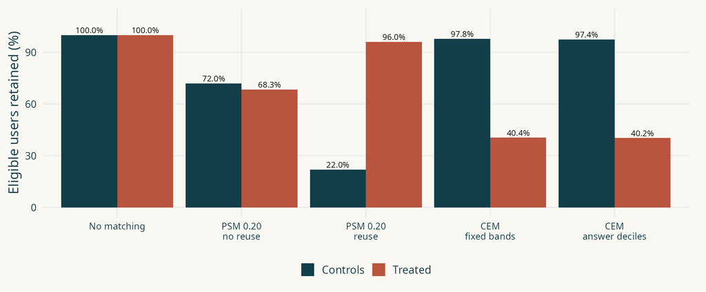

Eligible matching frame; controls and treated users shown separately. Both CEM designs and the 0.20 PSM designs are included.

Eligible matching frame; controls and treated users shown separately. Both CEM designs and the 0.20 PSM designs are included.

Coverage and balance answer different questions; retained populations are not identical.

## Balance in the four prior-history variables

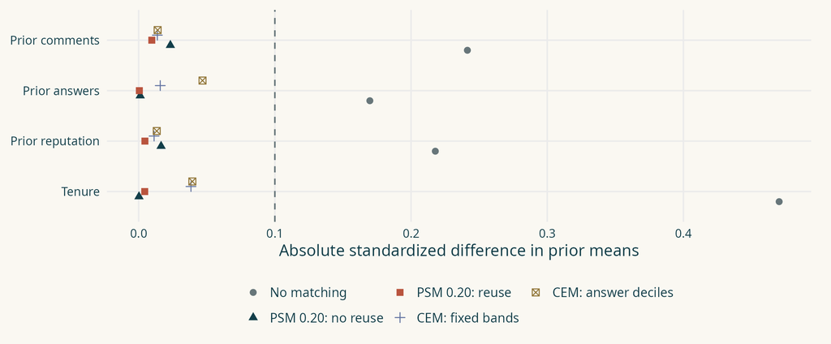

Fixed pre-match pooled standard deviations; absolute standardized mean gaps. The 0.10 line is a diagnostic reference.

Fixed pre-match pooled standard deviations; absolute standardized mean gaps. The 0.10 line is a diagnostic reference.

PSM and CEM balance the measured covariates to different degrees; this is not a test of parallel trends.

## How to read matching coverage and balance

| Column | Meaning |
| --- | --- |
| Maximum distance (SD) | Allowed gap in standard-deviation units; three limits increase together |
| Control reuse allowed? | Whether one control person may represent several treated users |
| Treated users matched (%) | Share of the 49,588 eligible treated users retained |
| Distinct controls | Number of different control people retained |
| Effective controls | Weight-based equivalent count; concentrated weights reduce it |
| Largest standardized gap | Largest absolute treated–control mean gap, in pooled SD units, across the four covariates |

SD = standard deviation. Effective count = (sum of weights)² / sum of squared weights. Reused controls remain people, not independent duplicate observations.

## Larger calipers: coverage and balance

| Maximum distance (SD) | Control reuse allowed? | Treated users matched (%) | Distinct controls | Effective controls | Largest standardized gap |
| --- | --- | --- | --- | --- | --- |
| 0.20 | No | 68.3% | 33,893 | 33,893 | 0.023 |
| 0.20 | Yes | 96.0% | 10,343 | 1,654 | 0.010 |
| 0.25 | No | 70.9% | 35,144 | 35,144 | 0.027 |
| 0.25 | Yes | 96.8% | 10,369 | 1,651 | 0.010 |
| 0.30 | No | 73.6% | 36,478 | 36,478 | 0.047 |
| 0.30 | Yes | 97.4% | 10,395 | 1,670 | 0.011 |

Outcome models are now estimated for **every row**, using the same 26 pre and 26 post weeks. The following figures compare their results.

The logit-propensity, prior-reputation and prior-answer distance limits increase together. The definitions are on the preceding slide.

## Caliper sensitivity: controls are not reused

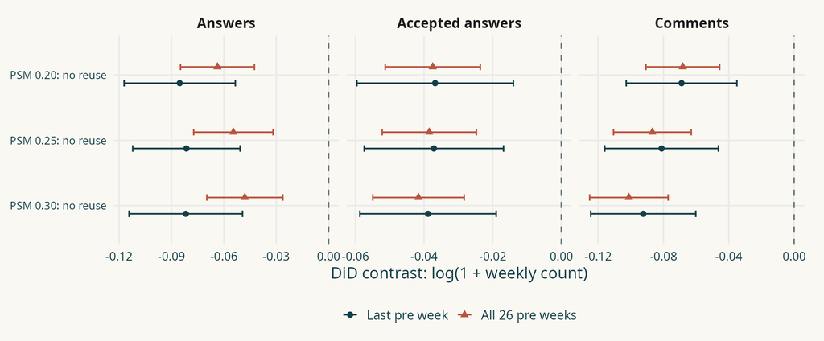

Estimated outcome DiD for calipers 0.20, 0.25 and 0.30; two time references; no contemporary activity control. 95% pointwise intervals, 1,000 user multiplier replications.

Estimated outcome DiD for calipers 0.20, 0.25 and 0.30; two time references; no contemporary activity control. 95% pointwise intervals, 1,000 user multiplier replications.

Compare effect size, uncertainty and the retained population together; changing a caliper changes the comparison group.

## Caliper sensitivity: controls may be reused

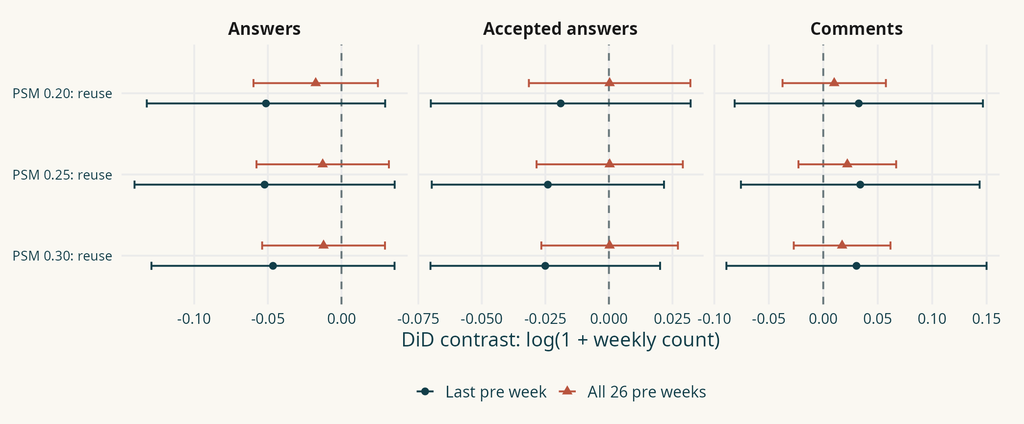

Estimated outcome DiD for calipers 0.20, 0.25 and 0.30; two time references; no contemporary activity control. 95% pointwise intervals, 1,000 user multiplier replications.

Estimated outcome DiD for calipers 0.20, 0.25 and 0.30; two time references; no contemporary activity control. 95% pointwise intervals, 1,000 user multiplier replications.

Compare effect size, uncertainty and the retained population together; changing a caliper changes the comparison group.

## Observed weekly counts: comments

| Design | Treated: pre | Treated: post | Controls: pre | Controls: post |
| --- | --- | --- | --- | --- |
| No matching | 2.61 | 2.85 | 1.19 | 2.35 |
| PSM 0.20: no reuse | 1.13 | 1.76 | 1.10 | 2.09 |
| PSM 0.20: reuse | 1.60 | 1.95 | 1.86 | 2.32 |
| CEM: fixed bands | 2.94 | 3.21 | 3.29 | 3.78 |
| CEM: answer deciles | 2.86 | 3.16 | 3.17 | 3.55 |

These are observed group means in original counts. A level difference is not the estimated DiD effect.

Same ±26 window; design-weighted user-week means, then equal weight to each observed group-week. Original active-week definition; no added inactive weeks.

## Activity effects: PSM and CEM, both time references

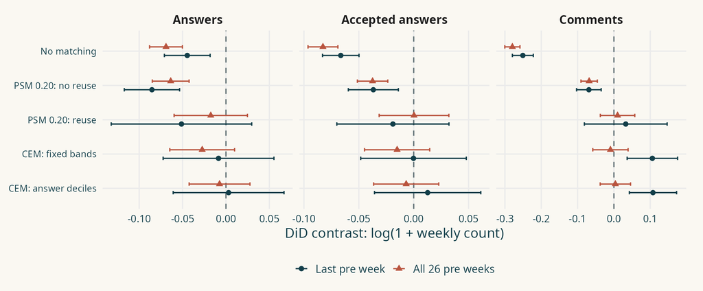

All five primary designs; ±26 weeks; two references; no contemporary activity control. 95% pointwise intervals from 1,000 user multiplier replications.

All five primary designs; ±26 weeks; two references; no contemporary activity control. 95% pointwise intervals from 1,000 user multiplier replications.

Each design retains different users and weights. A positive or negative DiD is a difference in changes, not necessarily an absolute rise or fall.

## Comments: the reference period matters

| Design | Reference: last pre week | Reference: all 26 pre weeks |
| --- | --- | --- |
| No matching | -0.251 [-0.280, -0.222] | -0.280 [-0.300, -0.259] |
| PSM 0.20: no reuse | -0.069 [-0.103, -0.035] | -0.068 [-0.091, -0.046] |
| PSM 0.20: reuse | +0.033 [-0.081, +0.147] | +0.010 [-0.037, +0.058] |
| CEM: fixed bands | +0.106 [+0.036, +0.175] | -0.010 [-0.058, +0.039] |
| CEM: answer deciles | +0.108 [+0.043, +0.173] | +0.004 [-0.038, +0.046] |

DiD estimates and 95% pointwise intervals, log(1 + weekly comments). The broad-pre model gives equal weight to each group-week.

## Why 52 observed weeks yield 51 weekly contrasts

| Object | Weeks used | Why the plotted count can differ |
| --- | --- | --- |
| Input activity window | 26 pre + 26 post = 52 | Every analysis uses the full required window |
| Weekly DiD with varying pre baseline | 25 pre contrasts + 26 post contrasts | The first pre week supplies the baseline for the first pre comparison |
| Weekly continuous GAM | 26 pre diagnostics + 26 post contrasts | Each week is compared with the user’s full pre-period mean |

Missing an estimable pre contrast is different from dropping an input week. Weekly axes use the same event-week labels from −26 to +26.

## Weekly answers: PSM comparisons

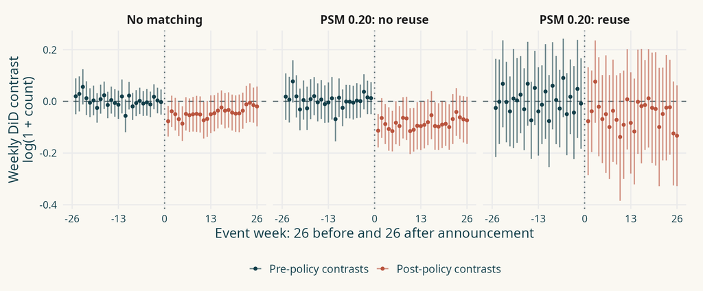

All 52 input weeks; 25 pre + 26 post contrasts. Last-pre reference for post effects; simultaneous 95% bands within each model.

All 52 input weeks; 25 pre + 26 post contrasts. Last-pre reference for post effects; simultaneous 95% bands within each model.

Read pre-policy diagnostics separately from post-policy estimates; groups use the same calendar window.

## Weekly answers: CEM comparisons

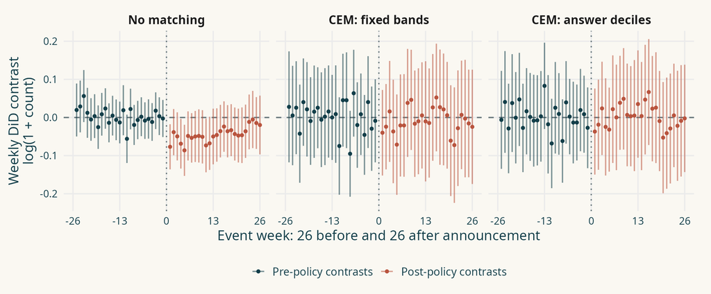

No matching, fixed-band CEM and answer-decile CEM; same ±26 input window and same outcome estimator. 1,000 user multiplier replications.

No matching, fixed-band CEM and answer-decile CEM; same ±26 input window and same outcome estimator. 1,000 user multiplier replications.

CEM is estimated for this outcome, not only shown as a sample-balance diagnostic.

## Weekly accepted answers: PSM comparisons

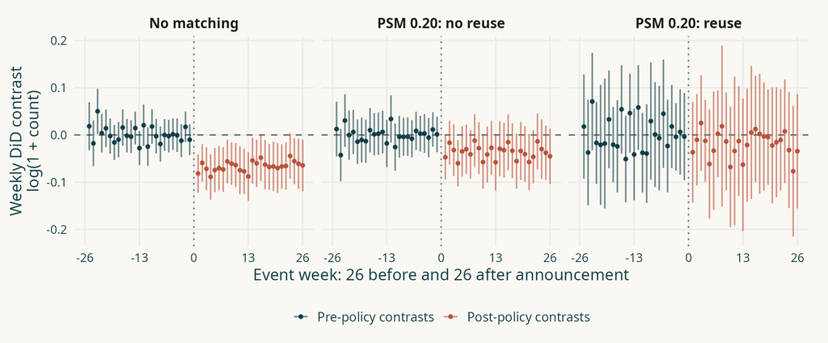

All 52 input weeks; 25 pre + 26 post contrasts. Last-pre reference for post effects; simultaneous 95% bands within each model.

All 52 input weeks; 25 pre + 26 post contrasts. Last-pre reference for post effects; simultaneous 95% bands within each model.

Read pre-policy diagnostics separately from post-policy estimates; groups use the same calendar window.

## Weekly accepted answers: CEM comparisons

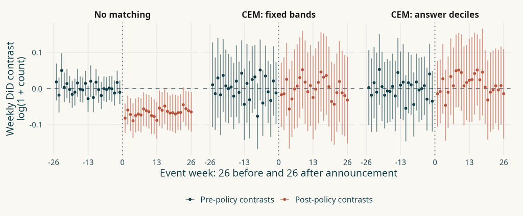

No matching, fixed-band CEM and answer-decile CEM; same ±26 input window and same outcome estimator. 1,000 user multiplier replications.

No matching, fixed-band CEM and answer-decile CEM; same ±26 input window and same outcome estimator. 1,000 user multiplier replications.

CEM is estimated for this outcome, not only shown as a sample-balance diagnostic.

## Weekly comments: PSM comparisons

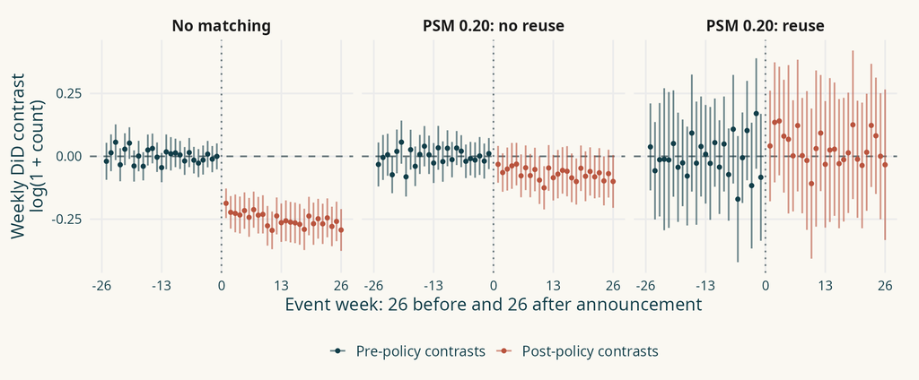

All 52 input weeks; 25 pre + 26 post contrasts. Last-pre reference for post effects; simultaneous 95% bands within each model.

All 52 input weeks; 25 pre + 26 post contrasts. Last-pre reference for post effects; simultaneous 95% bands within each model.

Read pre-policy diagnostics separately from post-policy estimates; groups use the same calendar window.

## Weekly comments: CEM comparisons

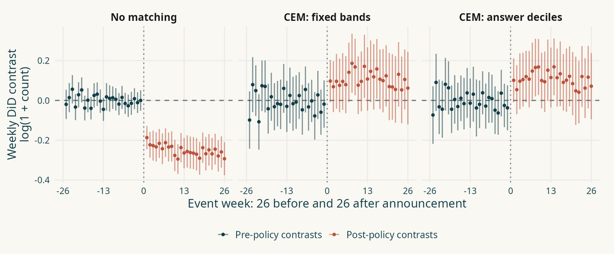

No matching, fixed-band CEM and answer-decile CEM; same ±26 input window and same outcome estimator. 1,000 user multiplier replications.

No matching, fixed-band CEM and answer-decile CEM; same ±26 input window and same outcome estimator. 1,000 user multiplier replications.

CEM is estimated for this outcome, not only shown as a sample-balance diagnostic.

## Continuous treatment: activity

Among users who actually lost reputation, what changes with a larger loss? Fit all eligible users; average where data support the proposed increase.

## Continuous treatment: shifts in relative loss

How does activity change with **15 percentage points more loss**, among users who actually lost reputation?

| Role | Model | What it allows |
| --- | --- | --- |
| **Main** | Additive GAM | The relationship can curve across loss levels. |
| **Appendix** | Linear dose × prior history | The loss slope can differ across prior histories, but stays constant across doses for a given history. |

The main GAM uses **six prior characteristics in their original units**, plus the pre-outcome mean. At the same starting loss, its shift contrast does not vary with history; the appendix model allows those interactions.

Same supported positive-loss question in both models. Dose = points lost / max(pre-policy reputation + 1, 1). +15 pp is focal; +5 to +25 pp are shown. Activity outcomes retain log(1 + count).

## What was this user like before the reform?

| What we control for | How we build it | Why it matters |
| --- | --- | --- |
| Prior activity | Three pre-announcement counts: comments, questions and answers | Heavy and occasional contributors start differently. |
| Prior reputation | Reputation before the announcement | Users start with different status. |
| Experience | Weeks from recorded user start to the announcement | New and established users may behave differently. |
| Asking vs answering | Pre-announcement questions / (questions + answers) | Users differ in their type of contribution. |
| Starting outcome | Mean pre-policy weekly outcome for that user | Compare changes given where the user started. |

**Six prior-history variables + one outcome baseline.** These are adjustment variables, not matched control users. We hold them fixed in both predictions; no current-week activity control enters.

Prior counts, reputation, experience and question share enter in their original units. Outcome baseline: mean of observed weekly log(1 + count). Exact construction follows in the code slide.

## Support means data near the higher loss

Example: a user lost **10%**. A **+15-pp** contrast needs information near **25% loss**.

| For this increment | What the data show | What we do |
| --- | --- | --- |
| **With support** | Enough users near 25% loss in the same broad prior-history group | Include the user in the +15-pp average |
| **Without support** | Too few such observations near 25% | Leave the user out of this average to limit extrapolation |

Support depends on the proposed increase: a user may qualify for +5 pp but not +15 pp. **No support does not mean no reputation loss.**

Our rule: ≥5 users in the 2.5-pp dose bin containing the shifted loss, within the same coarse history stratum. They are not exact matches. This practical check does not guarantee causal comparability.

## Compare the same history with 15 pp more loss

| Illustrative user | Loss used in first prediction | Loss used in second prediction |
| --- | --- | --- |
| A | 10% | 25% |
| B | 30% | 45% |

1. **Learn:** fit outcomes across eligible users with different losses, adjusting for prior history.
2. **Compare:** predict twice for each supported user with positive observed loss; change only their loss.
3. **Average:** shifted prediction minus observed-dose prediction, among supported users with positive observed loss.

There is **no single matched control user**, and comparison is not limited to zero-loss users. The alternative outcome is a model prediction, informed by observed users at different doses.

Support check: ≥5 users in the shifted 2.5-pp dose bin within the same broad history stratum. These are not five exact matches. Support and measured-history adjustment do not guarantee a causal interpretation.

## Support for each increment: main analysis

| Step | Main analysis | Why? |
| --- | --- | --- |
| Define the population | Users with **positive observed loss** | Study loss intensity among those actually affected |
| Check the proposed increase | Require support for **that increment** | Limit predictions with insufficient nearby data |
| Average the contrast | Use the users meeting both conditions | Target users can differ across increments |

A +15-pp comparison does not require support for +25 pp. Requiring all five increments is an additional restriction, preserved in the archived previous presentation.

Support uses the unchanged full eligible frame. Our 2.5-pp bins / ≥5 rule is a diagnostic heuristic, not a guarantee of causal identification. Lundberg & Brand (2026) motivate supported shifts; these thresholds and the positive-loss target are our choices.

## Continuous-dose controls use pre-reform history

```r
# Prior-history controls enter in ORIGINAL UNITS; no log/asinh transformations.
covariates = c("pre_comments", "tenure", "reputation_pre",
               "n_questions_pre", "n_answers_pre", "pct_questions_pre")
frame[, pct_questions_pre := fifelse(n_questions_pre + n_answers_pre > 0,
  n_questions_pre / (n_questions_pre + n_answers_pre), 0.5)]
# Counts and reputation precede the policy; tenure is in weeks.
# Outcome scale stays log(1 + weekly count); its baseline uses that same scale.
base = act[t_week < 0, .(base_comments = mean(comments)), by = user_id]
```

**Input.** Prior counts, reputation and experience; original observed weekly outcomes.

**Objects.** Six raw-scale history variables; `base_comments`: earlier mean of the outcome, not the historical comment total.

**Result.** Prior characteristics stay fixed when predicting observed loss and loss +15 pp. Target: positive observed loss and support.

We removed transformations of the **prior-history covariates**. The outcome and its baseline keep their established scale, so the shift contrast remains in the same units.

## Code behind the displayed dose estimates

```r
# act contains original OBSERVED active weeks; no added inactive-week zeros.
# period_delta(): each user's post mean minus pre mean; both periods required.
y = period_delta(act, c("answers", "accepted_answers", "comments"))
frame[, rel_loss := loss_points / pmax(reputation_pre + 1, 1)]
training = merge(frame, y, by = "user_id") # all eligible, valid pre/post outcomes
gam_fit = gam(comments ~ s(rel_loss, k=10) + s(pre_comments, k=6) +
    s(tenure, k=6) + s(reputation_pre, k=6) + s(n_questions_pre, k=6) +
    s(n_answers_pre, k=6) + s(pct_questions_pre, k=6) + s(base_comments, k=6),
    data = training, method = "REML")
target = training[rel_loss > 0 & supported_0.15 == TRUE]
shifted = copy(target)[, rel_loss := rel_loss + 0.15]
mean(predict(gam_fit, shifted) - predict(gam_fit, target))
# Fit once per outcome/model; use supported positive-loss target users for each increment.
# 200 bootstrap resamples of users; smoothing penalties held fixed during bootstrap refits.
```

**Input.** `act` → `y`: one pre/post change and baseline per user. `frame`: dose, earlier controls and support flags.

**Objects.** `training`: all eligible valid-outcome users; `gam_fit`: fitted relationships; `target` and `shifted`: prediction data.

**Result.** Mean shifted-minus-observed prediction → `estimates.csv`. `validation.csv` checks direct predictions and weighted refits.

Code excerpt: `56_continuous_activity_comments26.R and the fixed-basis helpers`. Objects are prepared by the full script.

**Completed specification:** fit all eligible valid-outcome users; average predictions only for supported positive-loss target users. Six history covariates + the pre-outcome level; no contemporary weekly-activity control.

## Model fitting and target population are different

| Step | Intuition |
| --- | --- |
| **Learn the pattern** | Fit the model with all eligible users with valid pre/post outcomes. |
| **Define the question** | Select users with positive observed loss and support for the chosen increment. |
| **Compare predictions** | Predict their change at actual loss and loss + increment; average the difference. |

```r
training = merge(frame, y, by = "user_id")  # all eligible, valid-outcome users
fit = gam(outcome_formula, data = training, method = "REML")
target = training[rel_loss > 0 & supported_0.15 == TRUE]   # only the averaging population
shifted = copy(target)[, rel_loss := rel_loss + 0.15]
mean(predict(fit, shifted) - predict(fit, target))
# User bootstrap refits use all training users; averages use target users only.
```

**Input.** `training`: 34,450 activity users with valid pre/post outcomes.

**Objects.** `fit` learns the relationship; `target` selects supported users with observed loss >0; `shifted` changes their dose only.

**Result.** At +15 pp: average over 9,066 activity users. `sample_plan.csv` records training and target sizes.

Code excerpt: `56_continuous_activity_comments26.R`. Objects are prepared by the full script.

**Completed and numerically checked.** Training: 34,450 activity users. At +15 pp, averages use 9,066 supported activity users. All 52 weekly activity fits follow.

## How to read a continuous-dose effect

| Step | Meaning |
| --- | --- |
| Outcome | Each user’s post-policy mean minus pre-policy mean of log(1 + weekly count) |
| Contrast | Predicted outcome at loss +15 pp minus predicted outcome at observed loss |
| Negative value | A lower predicted activity change with the larger loss |
| Positive value | A higher predicted activity change with the larger loss |

The graph shows a **difference between two predicted changes**. Counts on the slide identify whose predictions enter the average; they are not extra model coefficients to interpret.

Main: GAM with raw prior-history covariates. Average only among supported users with positive observed loss. Activity uses the full ±26-week window.

## Who enters each supported-shift average?

| Additional relative loss | Users fitting the model | Positive-loss users in the supported average |
| --- | --- | --- |
| +5 pp | 34,450 | 16,791 |
| +10 pp | 34,450 | 13,007 |
| +15 pp | 34,450 | 9,066 |
| +20 pp | 34,450 | 5,930 |
| +25 pp | 34,450 | 3,522 |

All averages now use 26 pre and 26 post weeks. Support is checked separately for each proposed dose increase.

Training includes all eligible users with valid pre/post activity. Targets require positive observed loss and support for that increment; populations can change across increments.

## Activity among users with loss: +5 pp

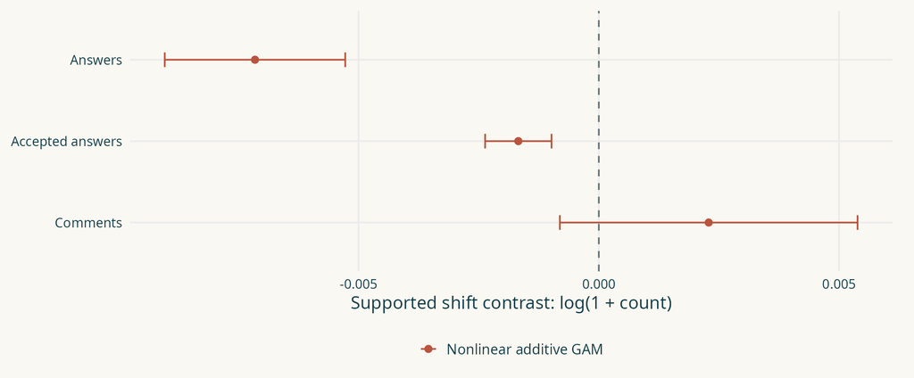

Re-estimated at ±26 weeks; 34,450 training users / 16,791 supported positive-loss targets. 200 bootstrap resamples of users; pointwise 95% intervals.

Re-estimated at ±26 weeks; 34,450 training users / 16,791 supported positive-loss targets. 200 bootstrap resamples of users; pointwise 95% intervals.

Answers: negative interval. Accepted answers: negative interval. Comments: interval includes zero.

## Activity among users with loss: +10 pp

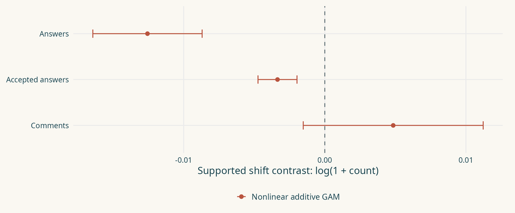

Re-estimated at ±26 weeks; 34,450 training users / 13,007 supported positive-loss targets. 200 bootstrap resamples of users; pointwise 95% intervals.

Re-estimated at ±26 weeks; 34,450 training users / 13,007 supported positive-loss targets. 200 bootstrap resamples of users; pointwise 95% intervals.

Answers: negative interval. Accepted answers: negative interval. Comments: interval includes zero.

## Activity among users with loss: +15 pp

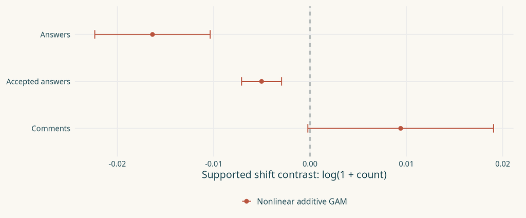

Re-estimated at ±26 weeks; 34,450 training users / 9,066 supported positive-loss targets. 200 bootstrap resamples of users; pointwise 95% intervals.

Re-estimated at ±26 weeks; 34,450 training users / 9,066 supported positive-loss targets. 200 bootstrap resamples of users; pointwise 95% intervals.

Answers: negative interval. Accepted answers: negative interval. Comments: interval includes zero.

## Activity among users with loss: +20 pp

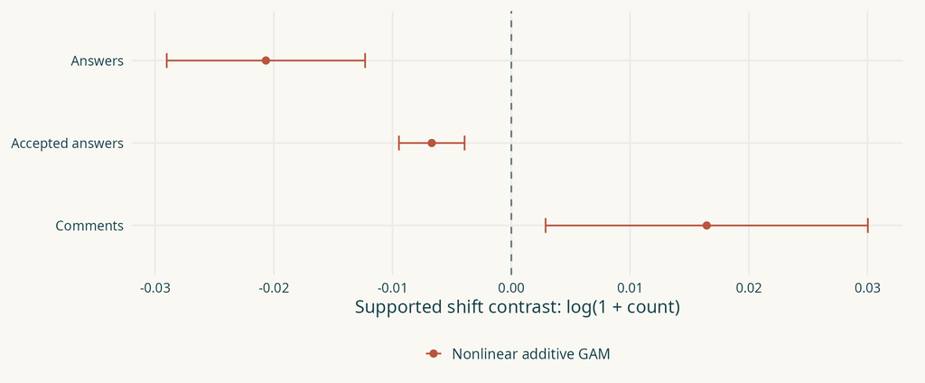

Re-estimated at ±26 weeks; 34,450 training users / 5,930 supported positive-loss targets. 200 bootstrap resamples of users; pointwise 95% intervals.

Re-estimated at ±26 weeks; 34,450 training users / 5,930 supported positive-loss targets. 200 bootstrap resamples of users; pointwise 95% intervals.

Answers: negative interval. Accepted answers: negative interval. Comments: positive interval.

## Activity among users with loss: +25 pp

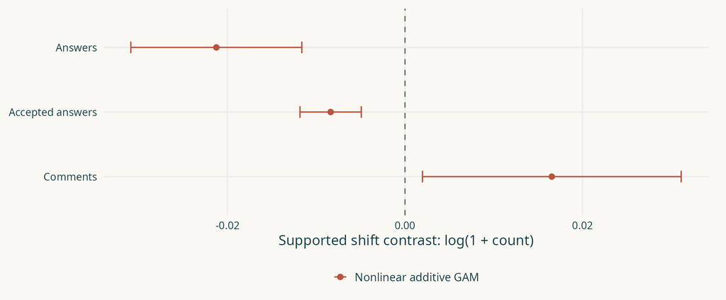

Re-estimated at ±26 weeks; 34,450 training users / 3,522 supported positive-loss targets. 200 bootstrap resamples of users; pointwise 95% intervals.

Re-estimated at ±26 weeks; 34,450 training users / 3,522 supported positive-loss targets. 200 bootstrap resamples of users; pointwise 95% intervals.

Answers: negative interval. Accepted answers: negative interval. Comments: positive interval.

## Weekly +15-pp contrasts: construction and uncertainty

```r
# Weekly outcome: log(1 + count) minus this user's mean over observed pre weeks.
weekly = weekly_dev(act, c("answers", "accepted_answers", "comments"))
d = merge(frame, weekly, by = "user_id")[t_week == week]
fit = bam(formula, data = d, method = "fREML")  # six raw-scale prior controls + pre-outcome mean
target = copy(d[rel_loss > 0 & supported_0.15 == TRUE])
shifted = copy(target)[, rel_loss := rel_loss + 0.15]
mean(predict(fit, shifted) - predict(fit, target))
# Repeat by week/outcome; 200 shared user bootstraps, fixed basis/penalties/support.
```

**Input.** Original observed weekly activity and pre-policy histories. No added inactive weeks.

**Objects.** `d`: all eligible users with this observed week and a valid pre mean; `fit`: weekly additive GAM with raw prior covariates; `target`: supported users with positive observed loss in that week.

**Result.** 156 weekly GAMs; 95% **pointwise** intervals from 200 bootstrap resamples of users. Direct predictions and an independent fixed-basis weighted QR refit numerically agree.

**Weekly question:** how does the +15-pp contrast vary over time? These trajectories use **only the additive GAM**, fitted separately each week. Pre-policy points are diagnostics; weekly samples change. They do not decompose the average effect or reproduce the binary DiD event study.

Training: 6,421–12,149 users per week; target: 1,492–2,860. Original panel week labels: −26…−1 and +1…+26. All 52 weeks are fitted.

## Weekly +15 pp among users with loss: answers

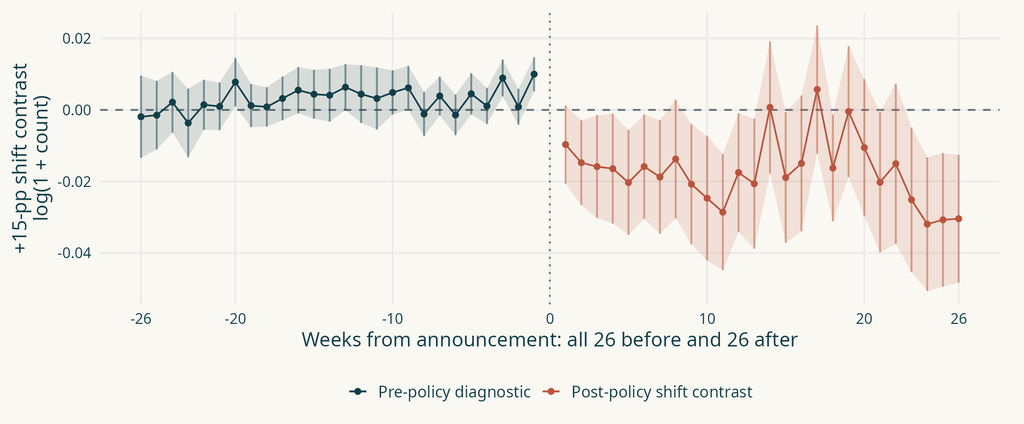

All 26 pre weeks and 26 post weeks estimated. Raw prior covariates; supported positive-loss users; 200 user bootstrap resamples; pointwise 95% intervals.

All 26 pre weeks and 26 post weeks estimated. Raw prior covariates; supported positive-loss users; 200 user bootstrap resamples; pointwise 95% intervals.

Pre-policy points are diagnostics. Target and fitting samples can change by week; the window stays fixed.

## Weekly +15 pp among users with loss: accepted answers

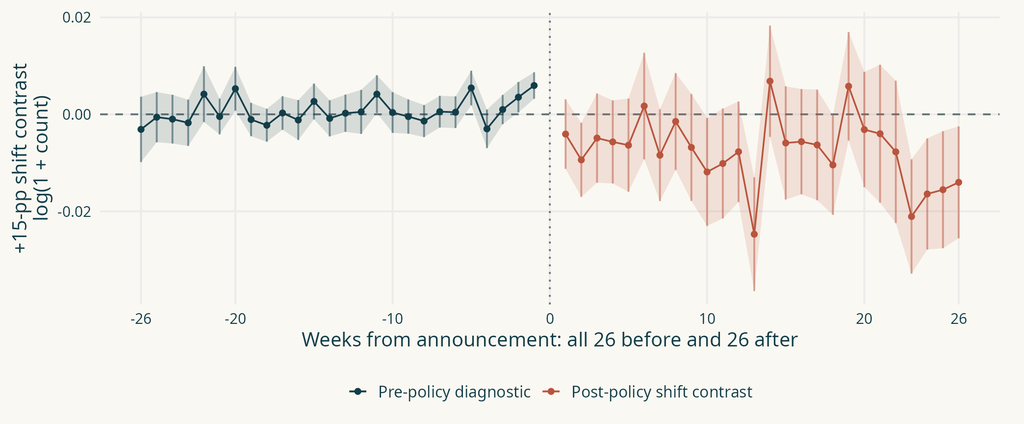

All 26 pre weeks and 26 post weeks estimated. Raw prior covariates; supported positive-loss users; 200 user bootstrap resamples; pointwise 95% intervals.

All 26 pre weeks and 26 post weeks estimated. Raw prior covariates; supported positive-loss users; 200 user bootstrap resamples; pointwise 95% intervals.

Pre-policy points are diagnostics. Target and fitting samples can change by week; the window stays fixed.

## Weekly +15 pp among users with loss: comments

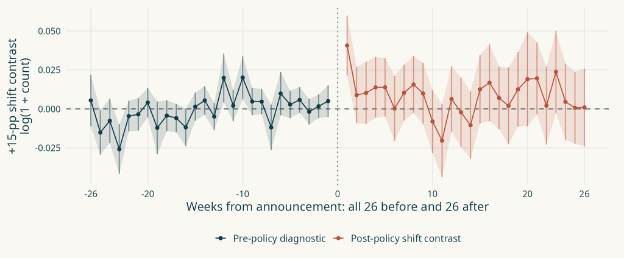

All 26 pre weeks and 26 post weeks estimated. Raw prior covariates; supported positive-loss users; 200 user bootstrap resamples; pointwise 95% intervals.

All 26 pre weeks and 26 post weeks estimated. Raw prior covariates; supported positive-loss users; 200 user bootstrap resamples; pointwise 95% intervals.

Pre-policy points are diagnostics. Target and fitting samples can change by week; the window stays fixed.

## Two continuous-treatment analyses, different contrasts

|  | Existing supported shifts | Additional continuous DiD |
| --- | --- | --- |
| Question | What changes with an extra +15 pp of loss? | What is the effect of dose d relative to zero loss? |
| Adjustment | Six prior characteristics + outcome baseline | No covariates in the official CCK implementation |
| Target | Positive-loss users supported for that increase | Valid-outcome users at each observed positive dose |
| Inference | 200 bootstrap resamples of users; pointwise intervals | 999 Gaussian multiplier replications; uniform curve bands |

**Both analyses are retained.** Different contrasts and adjustment choices can produce different results.

[Callaway, Goodman-Bacon & Sant’Anna, §3–4](https://arxiv.org/html/2107.02637v3) · [Authors’ implementation](https://bcallaway11.github.io/contdid/reference/cont_did.html). The new analysis uses the same pre/post fitting data, not the smaller shift-target population. Both activity fits now use ±26 weeks.

## Continuous DiD compares each dose with zero loss

ATT(d | d) = E[ΔY | D = d] − E[ΔY | D = 0]

| Element | Current implementation |
| --- | --- |
| Dose | Points lost / max(prior reputation + 1, 1) |
| Periods | User means over all 26 pre and 26 post weeks |
| Activity users | 34,450: 23,355 with loss; 11,095 without loss |
| Adjustment | Official CCK implementation, without covariates or matching weights |

Level effects require no anticipation and parallel untreated trends. Interpreting differences between doses causally requires stronger assumptions.

[Callaway, Goodman-Bacon & Sant’Anna, sections 3–4](https://arxiv.org/html/2107.02637v3). Two-period averaging does not itself test pretrends.

## The additional fit uses the preprint’s CCK estimator

```r
# Y: observed-week user mean; time: 1 = pre, 2 = post.
# dose is constant within user; G = 2 for positive loss, otherwise 0.
fit = contdid::cont_did(
  yname = "Y", dname = "dose", gname = "G", tname = "time",
  idname = "user_id", data = two_period_data, xformula = ~1,
  target_parameter = "level", aggregation = "dose",
  treatment_type = "continuous", dose_est_method = "cck",
  control_group = "nevertreated", cband = TRUE,
  bstrap = TRUE, biters = 999
)
```

Data-adaptive cubic B-splines estimate the dose curve. **CCK selects flexibility from the data**, rather than reusing our GAM.

999 Gaussian multiplier bootstrap replications for curve bands. Each user contributes one pre/post change. Uniform within each outcome, not across all three activity outcomes.

## Activity: continuous DiD relative to zero loss

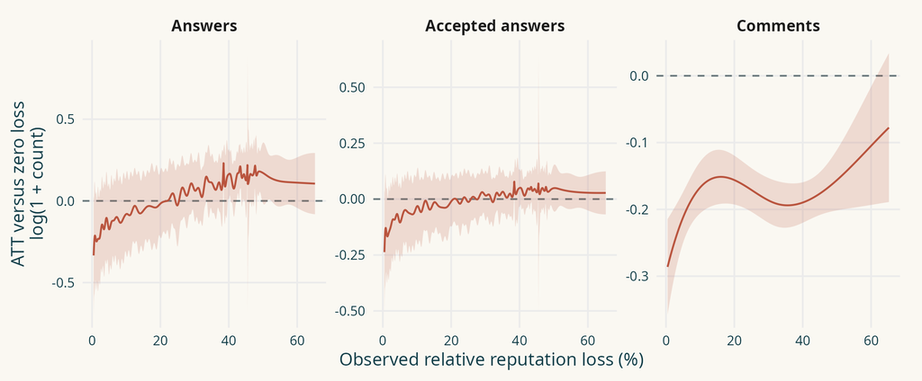

Re-estimated using ±26 activity means; official CCK curve; 999 Gaussian multiplier replications; uniform 95% bands within outcome. Central 98% of observed doses displayed; all eligible doses fitted.

Re-estimated using ±26 activity means; official CCK curve; 999 Gaussian multiplier replications; uniform 95% bands within outcome. Central 98% of observed doses displayed; all eligible doses fitted.

Each point describes the recipients of that dose relative to zero loss; it is a different contrast from an extra +15 pp.

## Continuous DiD: changes in both groups

| Outcome | Change among users with loss | Change among zero-loss users | Difference in changes [95% interval] |
| --- | --- | --- | --- |
| Answers | -0.058 | -0.103 | +0.045 [+0.034, +0.056] |
| Accepted answers | -0.013 | -0.010 | -0.004 [-0.011, +0.004] |
| Comments | -0.083 | +0.101 | -0.184 [-0.196, -0.171] |

The average effect compares positive loss with zero loss. It is not the effect of increasing the same user’s loss by 15 pp.

Full ±26-week user means; no covariate adjustment. Units: log(1 + count). 95% pointwise intervals for averages, unlike uniform curve bands.

## Text and context: ±26 weeks

The text analysis follows the same required 26 weeks before and 26 weeks after. The supplied raw comments cover the pre period; the post period is incomplete.

## The raw comment files cover the full pre period

| Raw source | Observed coverage | Contribution to required window |
| --- | --- | --- |
| comments_2009-12.json | 1 July – 31 December 2009 | Covers the first part of the 26-week pre period |
| comments_2010-06.json | 1 January – 30 June 2010 | Completes the pre period; covers part of the post period |
| Still required | 1 July – 16 September 2010 | Complete the remainder of the 26-week post period |

The earlier symmetric cut was an implementation choice. The current pipeline requires all 52 weeks and stops when text coverage is incomplete.

Coverage checked from every JSON record’s creation_date. A missing week is not a zero-emotion observation.

## Text re-estimation follows the same comparison designs

| Analysis step | Specification to retain |
| --- | --- |
| Raw extraction and scores | Full ±26 weeks; same VADER and GoEmotions definitions |
| Binary outcome comparisons | No matching, PSM at all three calipers, and both CEM designs |
| Continuous treatment | Supported shifts and the preprint’s continuous DiD |
| Context outcomes | The same full window; explicit opportunity and participation definitions |

Text coefficients are pending the missing raw post-period comments. The previous shorter-window results remain available in the archived presentation.

## Findings from the ±26-week activity analysis

PSM and CEM now enter the estimated outcome analyses, including both larger calipers and both time references.

The two continuous-treatment approaches are retained and re-estimated at ±26 weeks. Their effects answer different questions; compare their assumptions and populations alongside the estimates.

Text and context require the missing second-semester raw comments to meet the same window. Complete activity results and sensitivity figures.

## Activity sensitivity: weekly total contributions

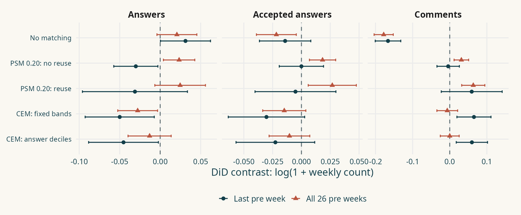

All primary PSM and CEM designs; both references; same ±26 window. 1,000 user multiplier replications; 95% pointwise intervals.

All primary PSM and CEM designs; both references; same ±26 window. 1,000 user multiplier replications; 95% pointwise intervals.

The contemporary activity control can respond to treatment; this is a conditional comparison.

## PSM without control reuse: activity adjustment 2

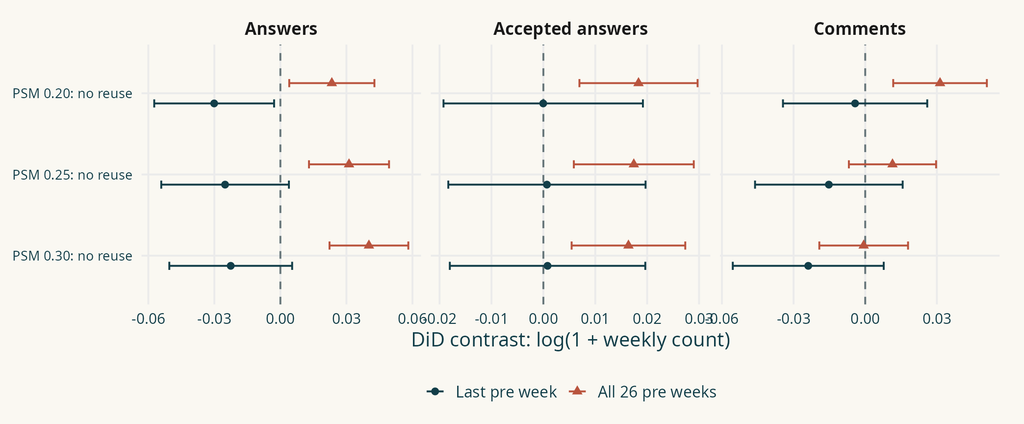

All three calipers have fitted outcome models under this adjustment; both time references; ±26 weeks.

All three calipers have fitted outcome models under this adjustment; both time references; ±26 weeks.

A changed caliper changes retained users and weights, as well as precision.

## PSM with control reuse: activity adjustment 2

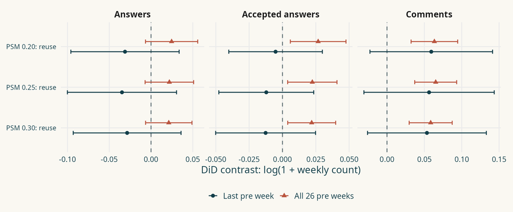

All three calipers have fitted outcome models under this adjustment; both time references; ±26 weeks.

All three calipers have fitted outcome models under this adjustment; both time references; ±26 weeks.

A changed caliper changes retained users and weights, as well as precision.

## CEM answers: activity adjustment 2

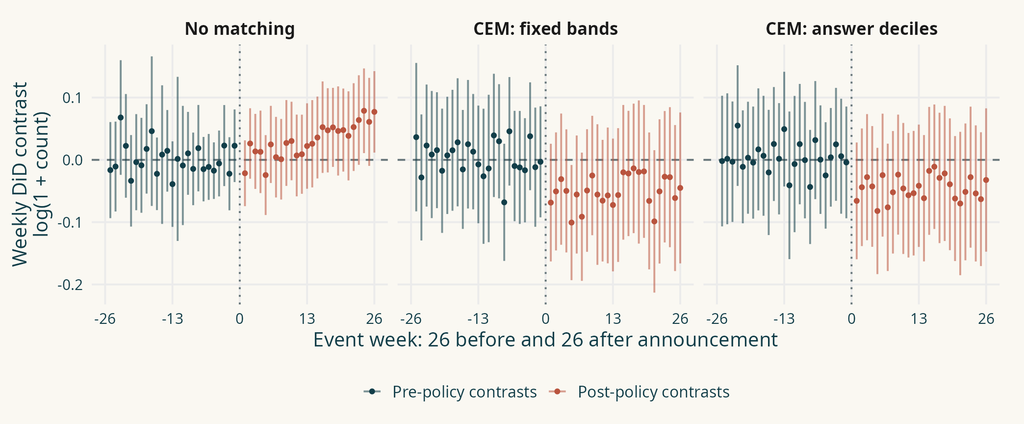

Same CEM weights, input window and regression-DiD estimator; simultaneous 95% bands within model.

Same CEM weights, input window and regression-DiD estimator; simultaneous 95% bands within model.

Inspect pre diagnostics and post estimates; no joint correction across all specifications.

## CEM accepted answers: activity adjustment 2

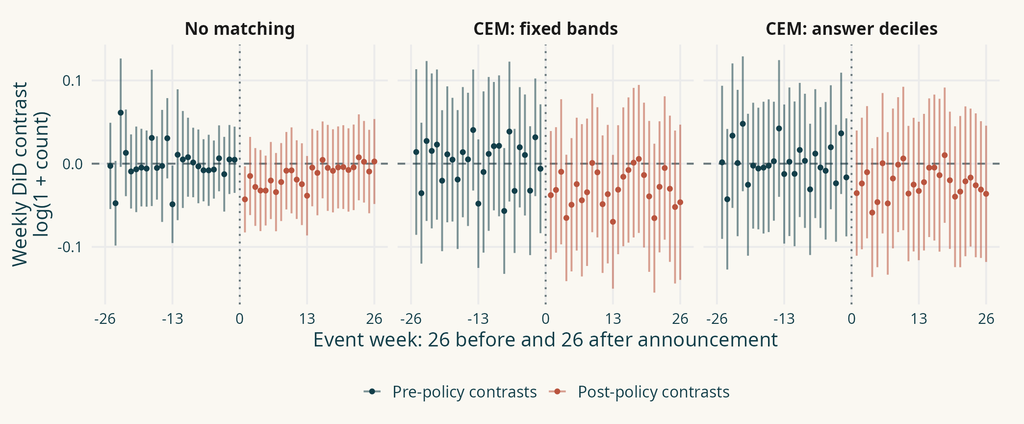

Same CEM weights, input window and regression-DiD estimator; simultaneous 95% bands within model.

Same CEM weights, input window and regression-DiD estimator; simultaneous 95% bands within model.

Inspect pre diagnostics and post estimates; no joint correction across all specifications.